# Cyclistic_Bike_Share_Analysis

Dhananjay Dewangan

2023-08-08

[figure not shown]

Cyclistic_Logo

## Case Study: How Does a Bike-Share Navigate Speedy Success?

### Introduction

Welcome to the Cyclistic bike-share analysis case study! In this case study, I am going to perform many real-world tasks of a junior data analyst, for a fictional company, Cyclistic, and meeting the different characters and team members. In order to answer the key business questions, I am following the steps of the data analysis process: ask, prepare, process, analyze, share, and act.

### Scenario

I am a junior data analyst working in the marketing analyst team at Cyclistic, a bike-share company in Chicago. The director of marketing believes the company’s future success depends on maximizing the number of annual memberships. Therefore, my team wants to understand how casual riders and annual members use Cyclistic bikes differently. From these insights, my team will design a new marketing strategy to convert casual riders into annual members. But first, Cyclistic executives must approve my recommendations, so they must be backed up with compelling data insights and professional data visualizations.

#### Characters and teams

● Cyclistic: A bike-share program that features more than 5,800 bicycles and 600 docking stations. Cyclistic sets itself apart by also offering reclining bikes, hand tricycles, and cargo bikes, making bike-share more inclusive to people with disabilities and riders who can’t use a standard two-wheeled bike. The majority of riders opt for traditional bikes; about 8% of riders use the assistive options. Cyclistic users are more likely to ride for leisure, but about 30% use them to commute to work each day.

● Lily Moreno: The director of marketing and your manager. Moreno is responsible for the development of campaigns and initiatives to promote the bike-share program. These may include email, social media, and other channels.

● Cyclistic marketing analytics team: A team of data analysts who are responsible for collecting, analyzing, and reporting data that helps guide Cyclistic marketing strategy. You joined this team six months ago and have been busy learning about Cyclistic’s mission and business goals — as well as how you, as a junior data analyst, can help Cyclistic achieve them.

● Cyclistic executive team: The notoriously detail-oriented executive team will decide whether to approve the recommended marketing program.

### About the company

In 2016, Cyclistic launched a successful bike-share offering. Since then, the program has grown to a fleet of 5,824 bicycles that are geotracked and locked into a network of 692 stations across Chicago. The bikes can be unlocked from one station and returned to any other station in the system anytime.

Until now, Cyclistic’s marketing strategy relied on building general awareness and appealing to broad consumer segments. One approach that helped make these things possible was the flexibility of its pricing plans: single-ride passes, full-day passes, and annual memberships. Customers who purchase single-ride or full-day passes are referred to as casual riders. Customers who purchase annual memberships are Cyclistic members.

Cyclistic’s finance analysts have concluded that annual members are much more profitable than casual riders. Although the pricing flexibility helps Cyclistic attract more customers, Moreno believes that maximizing the number of annual members will be key to future growth. Rather than creating a marketing campaign that targets all-new customers, Moreno believes there is a very good chance to convert casual riders into members. She notes that casual riders are already aware of the Cyclistic program and have chosen Cyclistic for their mobility needs.

**Moreno has set a clear goal** : Design marketing strategies aimed at converting casual riders into annual members. In order to do that, however, the marketing analyst team needs to better understand how annual members and casual riders differ, why casual riders would buy a membership, and how digital media could affect their marketing tactics. Moreno and her team are interested in analyzing the Cyclistic historical bike trip data to identify trends.

## Ask

Three questions will guide the future marketing program:

1. How do annual members and casual riders use Cyclistic bikes differently?
2. Why would casual riders buy Cyclistic annual memberships?
3. How can Cyclistic use digital media to influence casual riders to become members?

Moreno has assigned me the first question to answer: How do annual members and casual riders use Cyclistic bikes differently?

**Guiding questions**

1. What is the problem you are trying to solve?
2. How can your insights drive business decisions?

**Key tasks**

1. Identify the business task
2. Consider key stakeholders

**Deliverable**

1. A clear statement of the business task

## Prepare

We use Cyclistic’s historical trip data to analyze and identify trends.for downloading the previous 12 months of Cyclistic trip data [Click_Here](https://divvy-tripdata.s3.amazonaws.com/index.html). Note: The datasets have a different name because Cyclistic is a fictional company. For the purposes of this case study, the datasets are appropriate and enable us to answer the business questions.

The data has been made available by Motivate International Inc. under this [license](https://ride.divvybikes.com/data-license-agreement). This is public data that you can use to explore how different customer types are using Cyclistic bikes.

**Guiding questions**

1. Where is your data located?
2. How is the data organized?
3. Are there issues with bias or credibility in this data?
4. How are you addressing licensing, privacy, security, and accessibility?
5. How did you verify the data’s integrity?
6. How does it help you answer your question?
7. Are there any problems with the data?

**Key tasks**

1. Download data and store it appropriately.
2. Identify how it’s organized.
3. Sort and filter the data.
4. Determine the credibility of the data.

**Deliverable**

1. A description of all data sources used

We used the data of 12 months of the year 2022_divy_bike_trip_data provided by the Cyclistic Company

This step will prepare the data for analysis. All the csv files will be merged into one file to improve workflow

```r
# Loading Tidyverse Package
library(tidyverse)
```

### Uploading the Dataset

```r
data1 <- read_csv("202201_trip_data.csv")
data2 <- read_csv("202202_trip_data.csv")
data3 <- read_csv("202203_trip_data.csv")
data4 <- read_csv("202204_trip_data.csv")
data5 <- read_csv("202205_trip_data.csv")
data6 <- read_csv("202206_trip_data.csv")
data7 <- read_csv("202207_trip_data.csv")
data8 <- read_csv("202208_trip_data.csv")
data9 <- read_csv("202209_trip_data.csv")
data10 <- read_csv("202210_trip_data.csv")
data11 <- read_csv("202211_trip_data.csv")
data12 <- read_csv("202212_trip_data.csv")
```

**Joining all the data sets into one big data sets***

```r
# Joining all the data sets into one big data sets

all_data <- bind_rows(data1,data2,data3,data4,data5,data6,data7,data8,data9,data10,data11,data12)
```

**Removing Lat and lng**

```r
# Removing Lat and lng
all_data <- all_data %>% select(-c(start_lat, start_lng, end_lat, end_lng))
```

### Data Cleaning

**Removing Duplicates**

```r
all_data_clean<- all_data[!duplicated(all_data$ride_id), ]
print(paste("Removed", nrow(all_data) - nrow(all_data_clean), "duplicated rows"))
```

```
## [1] "Removed 1387 duplicated rows"
```

## Analyze

Now the data is processed appropriately and has been ready for analysis.

*Inspecting the Data*

```r
# colnames
colnames(all_data_clean)  #List of column names
```

```
##  [1] "ride_id"            "rideable_type"      "started_at"
##  [4] "ended_at"           "start_station_name" "start_station_id"
##  [7] "end_station_name"   "end_station_id"     "member_casual"
## [10] "ride_length"        "day_of_week"
```

```r
# nrow
nrow(all_data_clean)  #How many rows are in data frame?
```

```
## [1] 4385034
```

```r
# dim
dim(all_data_clean)  #Dimensions of the data frame?
```

```
## [1] 4385034      11
```

```r
# head
head(all_data_clean)  #See the first 6 rows of data frame.  Also tail(all_trips)
```

```
## # A tibble: 6 × 11
##   ride_id  rideable_type started_at ended_at start_station_name start_station_id
##   <chr>    <chr>         <chr>      <chr>    <chr>              <chr>
## 1 C2F7DD7… electric_bike 13-01-202… 13-01-2… Glenwood Ave & To… 525
## 2 A6CF898… electric_bike 10-01-202… 10-01-2… Glenwood Ave & To… 525
## 3 BD0F91D… classic_bike  25-01-202… 25-01-2… Sheffield Ave & F… TA1306000016
## 4 CBB80ED… classic_bike  04-01-202… 04-01-2… Clark St & Bryn M… KA1504000151
## 5 DDC963B… classic_bike  20-01-202… 20-01-2… Michigan Ave & Ja… TA1309000002
## 6 A39C6F6… classic_bike  11-01-202… 11-01-2… Wood St & Chicago… 637
## # ℹ 5 more variables: end_station_name <chr>, end_station_id <chr>,
## #   member_casual <chr>, ride_length <time>, day_of_week <dbl>
```

```r
# str
str(all_data_clean)  #See list of columns and data types (numeric, character, etc)
```

```
## tibble [4,385,034 × 11] (S3: tbl_df/tbl/data.frame)
##  $ ride_id           : chr [1:4385034] "C2F7DD78E82EC875" "A6CF8980A652D272" "BD0F91DFF741C66D" "CBB80ED419105406" ...
##  $ rideable_type     : chr [1:4385034] "electric_bike" "electric_bike" "classic_bike" "classic_bike" ...
##  $ started_at        : chr [1:4385034] "13-01-2022 11:59" "10-01-2022 08:41" "25-01-2022 04:53" "04-01-2022 00:18" ...
##  $ ended_at          : chr [1:4385034] "13-01-2022 12:02" "10-01-2022 08:46" "25-01-2022 04:58" "04-01-2022 00:33" ...
##  $ start_station_name: chr [1:4385034] "Glenwood Ave & Touhy Ave" "Glenwood Ave & Touhy Ave" "Sheffield Ave & Fullerton Ave" "Clark St & Bryn Mawr Ave" ...
##  $ start_station_id  : chr [1:4385034] "525" "525" "TA1306000016" "KA1504000151" ...
##  $ end_station_name  : chr [1:4385034] "Clark St & Touhy Ave" "Clark St & Touhy Ave" "Greenview Ave & Fullerton Ave" "Paulina St & Montrose Ave" ...
##  $ end_station_id    : chr [1:4385034] "RP-007" "RP-007" "TA1307000001" "TA1309000021" ...
##  $ member_casual     : chr [1:4385034] "casual" "casual" "member" "casual" ...
##  $ ride_length       : 'hms' num [1:4385034] 00:03:00 00:05:00 00:05:00 00:15:00 ...
##   ..- attr(*, "units")= chr "secs"
##  $ day_of_week       : num [1:4385034] 5 2 3 3 5 3 1 7 2 6 ...
```

```r
# summary
summary(all_data_clean)  #Statistical summary of data. Mainly for numerics
```

```
##    ride_id          rideable_type       started_at          ended_at
##  Length:4385034     Length:4385034     Length:4385034     Length:4385034
##  Class :character   Class :character   Class :character   Class :character
##  Mode  :character   Mode  :character   Mode  :character   Mode  :character
##
##
##
##  start_station_name start_station_id   end_station_name   end_station_id
##  Length:4385034     Length:4385034     Length:4385034     Length:4385034
##  Class :character   Class :character   Class :character   Class :character
##  Mode  :character   Mode  :character   Mode  :character   Mode  :character
##
##
##
##  member_casual      ride_length        day_of_week
##  Length:4385034     Length:4385034    Min.   :1.000
##  Class :character   Class1:hms        1st Qu.:2.000
##  Mode  :character   Class2:difftime   Median :4.000
##                     Mode  :numeric    Mean   :4.093
##                                       3rd Qu.:6.000
##                                       Max.   :7.000
```

**Descriptive analysis on ride_length (all figures in seconds)**

```r
# mean
mean(all_data_clean$ride_length)
```

```
## Time difference of 1018.042 secs
```

```r
# median
median(all_data_clean$ride_length)
```

```
## Time difference of 660 secs
```

```r
# max
max(all_data_clean$ride_length)
```

```
## Time difference of 86340 secs
```

```r
# min
min(all_data_clean$ride_length)
```

```
## Time difference of 0 secs
```

### Casuals vs members

How much of the data is about members and how much is about casuals?

```r
all_data_clean %>%
    group_by(member_casual) %>%
    summarise(count = length(ride_id),
              '%' = (length(ride_id) / nrow(all_data_clean)) * 100)
```

```
## # A tibble: 2 × 3
##   member_casual   count   `%`
##   <chr>           <int> <dbl>
## 1 casual        1762633  40.2
## 2 member        2622401  59.8
```

```r
# This function help to resize the plots
fig <- function(width, heigth){options(repr.plot.width = width, repr.plot.height = heigth)}
```

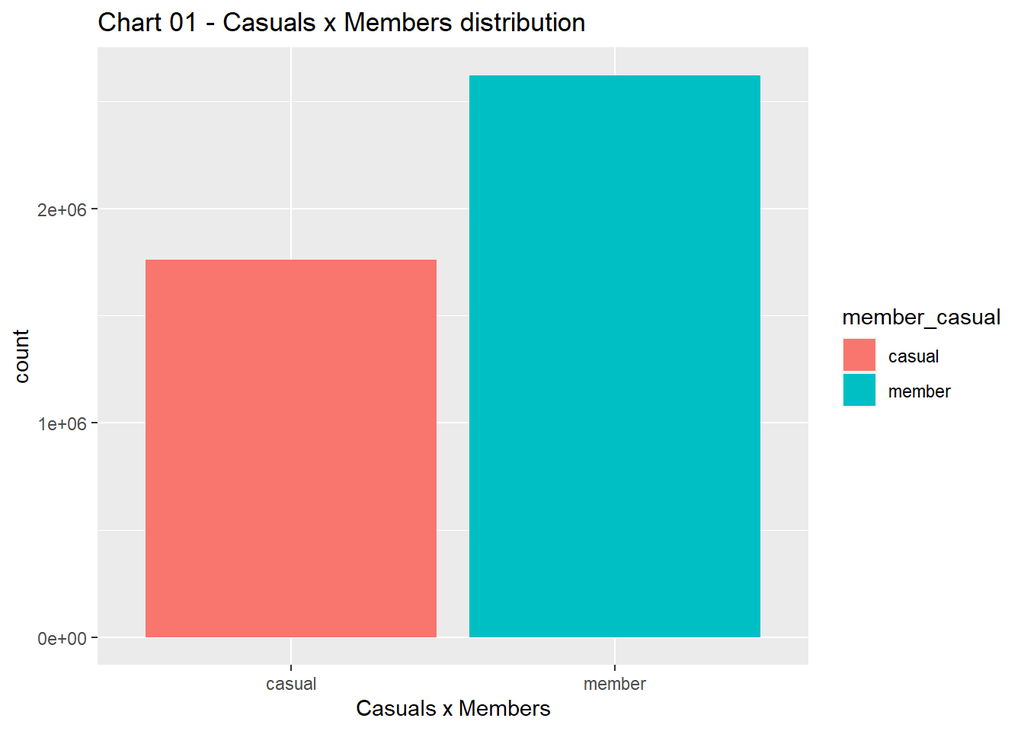

```r
fig(16,8)
ggplot(all_data_clean, aes(member_casual, fill=member_casual)) +
    geom_bar() +
    labs(x="Casuals x Members", title="Chart 01 - Casuals x Members distribution")
```

As we can see on the member x casual table, members have a bigger proportion of the dataset, composing ~59%, ~19% bigger than the count of casual riders.

**Compare members and casual users**

```r
aggregate(all_data_clean$ride_length ~ all_data_clean$member_casual, FUN = mean)
```

```
##   all_data_clean$member_casual all_data_clean$ride_length
## 1                       casual             1423.0078 secs
## 2                       member              745.8465 secs
```

```r
aggregate(all_data_clean$ride_length ~ all_data_clean$member_casual, FUN = median)
```

```
##   all_data_clean$member_casual all_data_clean$ride_length
## 1                       casual                   00:14:00
## 2                       member                   00:09:00
```

```r
aggregate(all_data_clean$ride_length ~ all_data_clean$member_casual, FUN = max)
```

```
##   all_data_clean$member_casual all_data_clean$ride_length
## 1                       casual                 86340 secs
## 2                       member                 86160 secs
```

```r
aggregate(all_data_clean$ride_length ~ all_data_clean$member_casual, FUN = min)
```

```
##   all_data_clean$member_casual all_data_clean$ride_length
## 1                       casual                     0 secs
## 2                       member                     0 secs
```

### Weekday

How much of the data is distributed by weekday?

```r
all_data_clean %>%
    group_by(day_of_week) %>%
    summarise(count = length(ride_id),
              '%' = (length(ride_id) / nrow(all_data_clean)) * 100,
              'members_p' = (sum(member_casual == "member") / length(ride_id)) * 100,
              'casual_p' = (sum(member_casual == "casual") / length(ride_id)) * 100,
              'Member x Casual Perc Difer' = members_p - casual_p)
```

```
## # A tibble: 7 × 6
##   day_of_week  count   `%` members_p casual_p `Member x Casual Perc Difer`
##         <dbl>  <int> <dbl>     <dbl>    <dbl>                        <dbl>
## 1           1 600490  13.7      49.7     50.3                       -0.507
## 2           2 587824  13.4      64.1     35.9                       28.1
## 3           3 609976  13.9      67.7     32.3                       35.4
## 4           4 618649  14.1      67.0     33.0                       34.0
## 5           5 648944  14.8      64.4     35.6                       28.9
## 6           6 611237  13.9      59.2     40.8                       18.4
## 7           7 707914  16.1      48.0     52.0                       -3.98
```

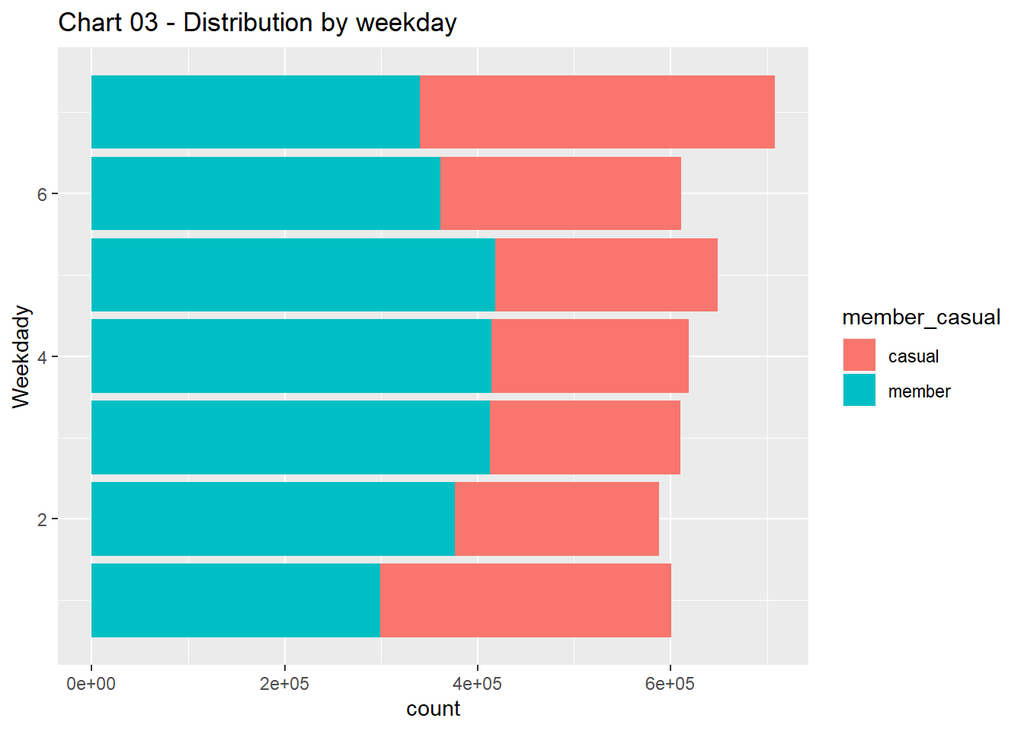

```r
ggplot(all_data_clean, aes(day_of_week, fill=member_casual)) +
    geom_bar() +
    labs(x="Weekdady", title="Chart 03 - Distribution by weekday") +
    coord_flip()
```

It’s interesting to see:

### Rideable type

```r
all_data_clean %>%
    group_by(rideable_type) %>%
    summarise(count = length(ride_id),
          '%' = (length(ride_id) / nrow(all_data_clean)) * 100,
          'members_p' = (sum(member_casual == "member") / length(ride_id)) * 100,
          'casual_p' = (sum(member_casual == "casual") / length(ride_id)) * 100,
          'member_casual_perc_difer' = members_p - casual_p)
```

```
## # A tibble: 3 × 6
##   rideable_type   count   `%` members_p casual_p member_casual_perc_difer
##   <chr>           <int> <dbl>     <dbl>    <dbl>                    <dbl>
## 1 classic_bike  2596660 59.2       65.8     34.2                     31.6
## 2 docked_bike    174852  3.99       0      100                     -100
## 3 electric_bike 1613522 36.8       56.7     43.3                     13.3
```

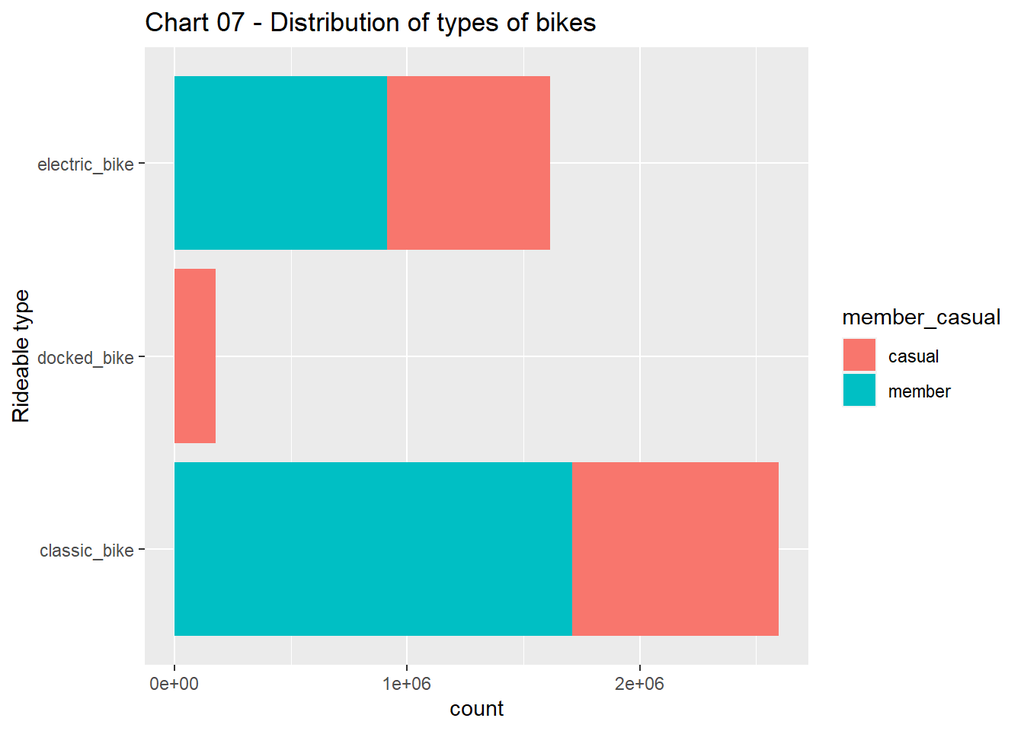

```r
ggplot(all_data_clean, aes(rideable_type, fill=member_casual)) +
    labs(x="Rideable type", title="Chart 07 - Distribution of types of bikes") +
    geom_bar() +
    coord_flip()
```

### Share

The Analysis phase is done and we got key insights from the analyis.

The Key finding are :

1. Members have the biggest proportion of the dataset, ~19% bigger thand casuals.
2. Members take more rides throughout the week vs casual users
3. Casual riders take less trips/rides but for longer durations of time vs members
4. In weekend the Casual riders used the most but in workdays the members used it most.
5. Majority of the people prefer classic bicycle may be ease of use.

**Conclusion** 1. Members use the bikes for fixed activities, one of those is going to work. 2. Bikes are used for recreation on the weekends.

### Act

The act phase would be done by the marketing team of the company. The main takeaway will be the top three recommendations for the marketing.

**Recomendations** 1. Giving offers to the casual riders in order to subscribe the membership of the company. 2. Giving discounts to the subscribers so that they can use for it long rides. 3. Establish more stations with charging facility in the city for bikes so the people can opt for electric bicycles, without any hesitation this can decrease the load of traditional classic bicycle.

****Thank You*****